# Inverse Estimation with Linear Mixed-Effects Models

with Application in R

Brandon M. Greenwell

January 15, 2017

Abstract

Inverse estimation, also known as inverse prediction or statistical calibration, is a classical and well-known problem in regression. In simple terms, it involves the use of an observed value of the response (or specified value of the mean response) to make inference on the corresponding unknown value of the explanatory variable. In this paper, we describe how to calculate approximate calibration confidence intervals for the unknown value of the explanatory variable in linear mixed-effects models using asymptotic methods and a parametric bootstrap. The converage probability for the asymptotic intervals is estimated as a function of sample size using a small Monte-Carlo simulation. Examples are given using the R programming language with a real data set.

## Introduction

Consider an ordinary regression model $\mathcal{Y}_i = f\left(x_i; \boldsymbol{\beta} \right) + \epsilon_i$ $(i = 1, ..., n)$, where $f$ is a known expectation function (called a *calibration curve* in this context) that is monotonic over the range of interest and $\epsilon_i \stackrel{iid}{\sim} \mathcal{N}\left( 0, \sigma^2 \right)$. A common problem in regression is to predict a future response $\mathcal{Y}_0$ (or estimate the mean response $f_0 = E\left[\mathcal{Y}_0\right]$) for a known value of the explanatory variable $x_0$. Often, however, there is a need to do the reverse; that is, given an observed value of the response $\mathcal{Y} = y_0$ (or a specified value of the mean response), infer the unknown value of the explanatory variable $x_0$. This is known as the *calibration problem*, though we refer to it more generally as inverse estimation.

A thorough overview of the calibration problem is given in Osborne (1991) and Greenwell (2014). Oman (1998) considers the case of a random intercept and slope model and provides an approximate parametric bootstrap algorithm for inferring $x_0$ (the algorithm we present later is fully parametric).

This paper concerns inverse estimation with linear mixed-effects models (LMMs); however, the methods presented here can be extended to generalized least-squares (GLS), nonlinear mixed-effects models (NLMMS) and generalized linear mixed-effects models as well. In particular, we extend the application of calibration to *grouped data*; that is, data in which the observations are grouped into disjoint classes called clusters or groups. Common examples of grouped data include *repeated measures data* and *longitudinal data*. Groups tend to be homogeneous, therefore, observations belonging to the same group cannot be considered independent. (Although, observations between clusters usually are.) Thus, we need to account for within cluster dependence when modeling this type of data. To our knowledge, other than Oman (1998), very little has been done for calibration with grouped data. Oman considered a simpler model that only allowed for the intercept and slope to vary between groups, whereas we take a more general (and practical) approach that allows for an arbitrary random effects structure. Furthermore, while Oman considers only one type of calibration interval, we discuss four different calibration intervals that can be computed for grouped data, along with some adjustments to improve their accuracy. Moreover, the calibration interval considered by Oman was based on an approximate parametric bootstrap that did not account for the variance attributed by the random variable $\mathcal{Y}_0$.

### Linear mixed-effects models

In practice, multiple observations are often taken from the same subject or experimental unit. This type of data is called *repeated measures* data. This includes, for example, *longitudinal* data or *panel* data (where experimental units are observed over time). The one feature to remember about repeated measures is that the individual observations are no longer independent. This feature must be taken into account in order to obtain valid standard errors, confidence intervals, etc. One of the most common and flexible ways for handling repeated measures data is to use LMMs.

LMMs (i.e., linear regression models with random coefficients) can be represented in many different, but equivalent forms. One of the most common forms, attributed to Laird and Ware (1982), is
$$\boldsymbol{\mathcal{Y}}_i = \boldsymbol{X}_i\boldsymbol{\beta} + \boldsymbol{Z}_i\boldsymbol{b}_i + \boldsymbol{\epsilon}_i, \quad i = 1, ..., m, \qquad (1)$$
where

- $\boldsymbol{\mathcal{Y}}_i$ is an $n_i \times 1$ response vector for the $i$-th subject/cluster/group;
- $\boldsymbol{X}_i$ is an $n_i \times p$ design matrix for the fixed-effects;
- $\boldsymbol{Z}_i$ is an $n_i \times q$ design matrix for the random-effects;
- $\boldsymbol{\beta}$ is a $p \times 1$ vector of fixed-effects coefficients;
- $\boldsymbol{b}_i$ is a $q \times 1$ vector of random-effects coefficients with mean zero and variance-covariance matrix $\boldsymbol{D}$;
- $\boldsymbol{D}$ is a $q \times q$ variance-covariance matrix for the random-effects;
- $\boldsymbol{\epsilon}_i$ is an $n_i \times 1$ vector of random errors with mean zero and variance-covariance matrix $\sigma^2\boldsymbol{I}$.

The random-effects $\boldsymbol{b}_i$ and errors $\boldsymbol{\epsilon}_i$ are often assumed to follow a normal distribution. By stacking the data, the (normal) LMM can be written concisely as
$$\boldsymbol{\mathcal{Y}} = \boldsymbol{X}\boldsymbol{\beta} + \boldsymbol{Z}\boldsymbol{b} + \boldsymbol{\epsilon}, \quad
\begin{bmatrix}
\boldsymbol{b} \\
\boldsymbol{\epsilon}
\end{bmatrix} \sim
\mathcal{N}\left(\begin{bmatrix}
\boldsymbol{0} \\
\boldsymbol{0}
\end{bmatrix}, \begin{bmatrix}
\boldsymbol{D} & \boldsymbol{0} \\
\boldsymbol{0} & \sigma^2\boldsymbol{I}
\end{bmatrix}\right),$$
where $\boldsymbol{\mathcal{Y}} = col\left\{\boldsymbol{\mathcal{Y}}_i\right\}$, $\boldsymbol{X} = col\left\{\boldsymbol{X}_i\right\}$, $\boldsymbol{Z} = diag\left\{\boldsymbol{Z}_i\right\}$, $\boldsymbol{b} = col\left\{\boldsymbol{b}_i\right\}$, and $\boldsymbol{\epsilon} = col\left\{\boldsymbol{\epsilon}_i\right\}$ for $i = 1, ..., m$. Since $COV\left[\boldsymbol{b}, \boldsymbol{\epsilon}\right] = \boldsymbol{0}$, it is assumed that the random vectors $\big\{ \boldsymbol{b}_i, \boldsymbol{\epsilon}_i \big\}_{i=1}^m$ are mutually independent.

The additional term $\boldsymbol{Z}\boldsymbol{b}$ in the model imposes a specific variance-covariance structure on the response vector $\boldsymbol{\mathcal{Y}}$:
$$\boldsymbol{\mathcal{Y}} \sim \mathcal{N}\left(\boldsymbol{X}\boldsymbol{\beta}, \boldsymbol{V}\right), \quad \boldsymbol{V} = \boldsymbol{Z}\boldsymbol{D}\boldsymbol{Z}^\top + \sigma^2\boldsymbol{I}.$$
Thus, the fixed-effects determine the mean of $\boldsymbol{\mathcal{Y}}$, while the random-effects govern the variance-covariance structure of $\boldsymbol{\mathcal{Y}}$. Different random-effects structures impose different variance-covariance structures on the response resulting in a highly flexible framework for modelling repeated measures.

The random-effects variance-covariance matrix $\boldsymbol{D}$ has at most $q(q+1)/2$ unique elements which we represent by the vector $\boldsymbol{\theta}$. There are a number of methods available for estimating $\left( \boldsymbol{\beta}, \sigma^2, \boldsymbol{\theta} \right)$; see, for example, McCulloch, Searle, and Neuhaus (2008), chap. 6, and Demidenko (2013), chap. 2. Most commonly, the fixed-effects $\boldsymbol{\beta}$ are estimated via the method of maximum likelihood (ML), while the variance components $\left(\sigma^2, \boldsymbol{\theta}\right)$ are estimated via restricted maximum likelihood (REML). The ML estimator of $\boldsymbol{\beta}$, given by
$$\widehat{\boldsymbol{\beta}} = \left( \boldsymbol{X}^\top \widehat{\boldsymbol{V}}^{-1} \boldsymbol{X} \right)\boldsymbol{X}^\top\boldsymbol{\mathcal{Y}},$$
depends on the estimated variance components through $\widehat{\boldsymbol{V}}$ which makes it difficult to capture the variability of $\widehat{\boldsymbol{\beta}}$ in small sample sizes (see McCulloch, Searle, and Neuhaus 2008, 165–67). The usual practice is to ignore the variability of the estimated variance components when making inference about the fixed-effects; that is, treat $\widehat{\boldsymbol{V}}$ as the true (fixed) value of $\boldsymbol{V}$. Modern computational procedures such as the parametric bootstrap and Markov chain Monte Carlo (MCMC) methods are two ways of accounting for the variability of the estimated variance components.

## Point estimation for $x_0$

The standard methods of calibration, (i.e., the Wald-based and inversion confidence intervals) are easily extended to the case of random coefficients. For convenience, let us rewrite the LMM (1) as
$$\mathcal{Y}_{ij} = f\left(x_{ij}; \boldsymbol{\beta}\right) + R\left(x_{ij}; \boldsymbol{b}_i\right) + \epsilon_{ij},$$
where $f(\cdot)$ and $R(\cdot)$ are linear in $\boldsymbol{\beta}$ and $\boldsymbol{b}_i$, respectively. For instance, the random intercept and slope model has $f\left(V_{ij}; \boldsymbol{\beta}\right) = \beta_0 + \beta_1 V_{ij}$ and $R\left(V_{ij}; \boldsymbol{b}_i\right) = b_{0i} + b_{1i}V_{ij}$ with $E\left[R\left(V_{ij}; \boldsymbol{b}_i\right)\right] = 0$ and $VAR\left[R\left(V_{ij}; \boldsymbol{b}_i\right)\right] = \theta_0^2 + V_{ij}^2\theta_1^2$.

Assume that, after the data are collected and a model is fitted, we obtain a new observation, denoted $\mathcal{Y}_0$, from the same population under study for which the value of the explanatory variable $x_0$ is unknown. We assume that the new observation belongs to a group not included in our analysis. Estimating $x_0$ is rather straightforward. By assumption, the new observation $\mathcal{Y}_0$ is distributed as a $\mathcal{N}\left\{f\left(x_0; \boldsymbol{\beta}\right), \sigma_0^2\right\}$ random variable with $\sigma_0^2 = VAR\left[ R\left( x_0; \boldsymbol{b}_0 \right) \right ] + \sigma^2$. A natural estimator for $x_0$ is obtained by inverting $f$ to obtain
$$\widehat{x}_0 = f^{-1}\left(\mathcal{Y}_0; \widehat{\boldsymbol{\beta}}\right), \qquad (2)$$
where $\widehat{\boldsymbol{\beta}}$ is the ML estimator of $\boldsymbol{\beta}$. We shall refer to Equation (2) as the inverse estimator. Note that the point estimate $\widehat{x}_0$ does not involve any of the random-effects; the random-effects only contribute to the variance-covariance structure of the response. Further arguments for the use of (2) as an estimate for $x_0$ are given in Greenwell (2014), Section 5.2.

## Wald interval for $x_0$

There is no “textbook” formula for $SE\left[\widehat{x}_0\right]$, the standard error of $\widehat{x}_0$—not even in the case of the simple linear regression model with i.i.d. Gaussian errors. Instead, an estimate of the standard error can be obtained using a first-order Taylor series approximation, or better yet, a parametric bootstrap approximation. Once we have $SE\left[\widehat{x}_0\right]$ an approximate $1 - \alpha$ Wald-type confidence interval for $x_0$ can be formed as
$$CI_W\left(x_0\right) = \left( \widehat{x}_0 - SE\left[\widehat{x}_0\right]\Phi^{-1}\left(\alpha/2\right), \widehat{x}_0 - SE\left[\widehat{x}_0\right]\Phi^{-1}\left(1-\alpha/2\right) \right), \qquad (2)$$
where $\Phi^{-1}$ is the probit function.

The Taylor series approximation to $SE\left[\widehat{x}_0\right]$ relies on the variance-covariance matrix of $\left(\mathcal{Y}_0, \widehat{\boldsymbol{\beta}}\right)^\top$; namely,
$$\Sigma = \begin{bmatrix}
VAR\left[\mathcal{Y}_0\right] & \boldsymbol{0} \\
\boldsymbol{0} & VAR\left[\widehat{\boldsymbol{\beta}}\right]
\end{bmatrix} = \begin{bmatrix}
\sigma_0^2 & \boldsymbol{0} \\
\boldsymbol{0} & \left(\boldsymbol{X}^\top\boldsymbol{V}^{-1}\boldsymbol{X}\right)^{-1}
\end{bmatrix}.$$
Since $\mathcal{Y}_0$ is independent of $\boldsymbol{\mathcal{Y}}$, it is also independent of $\widehat{\boldsymbol{\beta}}$, hence the diagonal structure of $\Sigma$. Recall that our point estimate has the form $x = f^{-1}\left(y; \boldsymbol{\beta}\right)$. Let $f_1^{-1}\left(y; \boldsymbol{\beta}\right)$ and $f_2^{-1}\left(y; \boldsymbol{\beta}\right)$ denote the partial derivatives of $f^{-1}$ with respect to the parameters $y$ and $\boldsymbol{\beta}$, respectively. A first-order Taylor-series approximation for the variance of $\widehat{x}_0$ is given by
$$VAR\left[\widehat{x}_0\right] \approx \left[f_1^{-1}\left(\mathcal{Y}_0; \widehat{\boldsymbol{\beta}}\right)\right]^2\sigma_0^2
+ \left[f_2^{-1}\left(\mathcal{Y}_0; \widehat{\boldsymbol{\beta}}\right)\right]^\top\left(\boldsymbol{X}^\top\boldsymbol{V}^{-1}\boldsymbol{X}\right)^{-1}\left[f_2^{-1}\left(\mathcal{Y}_0; \widehat{\boldsymbol{\beta}}\right)\right].$$
To obtain $SE\left[\widehat{x}_0\right] = \Big\{ \widehat{VAR}\left[\widehat{x}_0\right] \Big\}^{1/2}$, we simply replace $\sigma_0^2$ and $\boldsymbol{V}$ with their respective estimates $\widehat{\sigma}_0^2$ and $\widehat{\boldsymbol{V}}$.

Alternatively, one can use the parametric bootstrap instead of relying on a first-order Taylor series; this is discussed in a later section. The bootstrap estimate may be more accurate in smaller sample sizes because, unlike the Taylor series approximation, it takes into account the variability of the estimated variance components $\widehat{\sigma}_0^2$ and $\widehat{\boldsymbol{V}}$. The `bootMer` function in the `lme4` package (D. Bates et al. 2014) can be used for model-based parametric bootstrapping in mixed-effects models.

## Inversion interval for $x_0$

In the case of the simple linear regression model with i.i.d. Gaussian errors, an exact $1 - \alpha$ confidence interval for $x_0$ can be derived (see, for example, Graybill 1976). This can be generalized to an approximate method in the case of polynomial and nonlinear regression models with i.i.d. Gaussian errors (see, for example, Seber and Wild (2003) and Huet (2004)). In a similar fashion, we can generalize the same results to an approximate method for linear mixed-effects models.

Let $\widehat{f}_0 = f\left(x_0; \widehat{\boldsymbol{\beta}}\right)$ be the predicted mean at $x = x_0$. A prediction interval for $\mathcal{Y}_0$ at $x_0$ with asymptotic coverage probability $1 - \alpha$ is
$$\mathcal{I}_\infty\left(x_0\right) = \widehat{f}_0 \pm z_{1-\alpha/2}\left\{ \widehat{VAR}\left[\mathcal{Y}_0 - \widehat{f}_0\right] \right\}^{1/2}.$$
If instead, $\mathcal{Y}_0$ is observed to be $y_0$ and $x_0$ is unknown, then an asymptotic $1 - \alpha$ confidence interval for the unknown $x_0$ can be obtained by inverting $\mathcal{I}_\infty\left(x_0\right)$:
$$CI_I\left(x_0\right) = \left\{ x: z_{\alpha/2} \le \frac{\mathcal{Y}_0-f\left(x; \widehat{\boldsymbol{\beta}}\right)}{\left\{ \widehat{VAR}\left[\mathcal{Y}_0 - f\left(x; \widehat{\boldsymbol{\beta}}\right)\right] \right\}^{1/2}} \le z_{1-\alpha/2} \right\}. \qquad (3)$$
This is known as the *inversion interval* and typically cannot be written in closed-form; therefore, numerical techniques are required to find the lower and upper bounds. Further, note that $CI_I\left(x_0\right)$ is not symmetric about $\widehat{x}_0$ and will not necessarily result in a single finite interval (see, for example, Greenwell and Kabban 2014).

Fortunately, $CI_I\left(x_0\right)$ can be computed numerically using the `investr` package. However, like the Wald-based interval $CI_W\left(x_0\right)$, the inversion interval $CI_I\left(x_0\right)$ ignores the variability of the estimated variance components and will likely perform poorly in small sample sizes. An alternative approach involving the parametric bootstrap will be discussed in a later section.

Finally, the inversion interval uses a normal approximation. While it is likely that a $t$-distribution may be more accurate, it is difficult to find the appropriate degrees of freedom. Oman (1998), suggests a $t$-distribution with $N-1$ degrees of freedom ($N$ being the total sample size).

### Monte carlo study

To assess the empirical performance of $CI_W\left(x_0\right)$ and $CI_I\left(x_0\right)$, we carried out a small Monte Carlo study. The simulation described in this section was conducted in R using packages `plyr` (Wickham 2011), `nlme`, and `lme4`; the source code can be made available upon request to the authors. The results are reported in Table 1 and indicate that both $CI_W\left(x_0\right)$ $CI_I\left(x_0\right)$ have asymptotic coverage probability close to $1 - \alpha$. The main point of this experiment is to highlight the fact that it is the number of subjects $m$, not the sample size per subject $n$, that has the biggest impact on the asymptotic coverage probability.

| $m$ | Method | $n = 5$ | $n = 10$ | $n = 30$ | $n = 50$ | $n = 100$ |
| --- | --- | --- | --- | --- | --- | --- |
| 5 | Wald | 0.89 | 0.89 | 0.89 | 0.87 | 0.89 |
|  | Inversion | 0.89 | 0.90 | 0.89 | 0.88 | 0.90 |
| 10 | Wald | 0.92 | 0.92 | 0.94 | 0.93 | 0.93 |
|  | Inversion | 0.92 | 0.92 | 0.94 | 0.94 | 0.93 |
| 30 | Wald | 0.95 | 0.95 | 0.95 | 0.94 | 0.95 |
|  | Inversion | 0.94 | 0.94 | 0.94 | 0.94 | 0.95 |
| 50 | Wald | 0.95 | 0.96 | 0.95 | 0.94 | 0.94 |
|  | Inversion | 0.94 | 0.95 | 0.95 | 0.94 | 0.94 |
| 100 | Wald | 0.95 | 0.95 | 0.95 | 0.94 | 0.94 |
|  | Inversion | 0.95 | 0.95 | 0.95 | 0.94 | 0.95 |

Table 1. Estimated coverage probability for $CI_W\left(x_0\right)$ and $CI_I\left(x_0\right)$ as a function of the number of subjects (rows) and the number of observations per subject (columns).

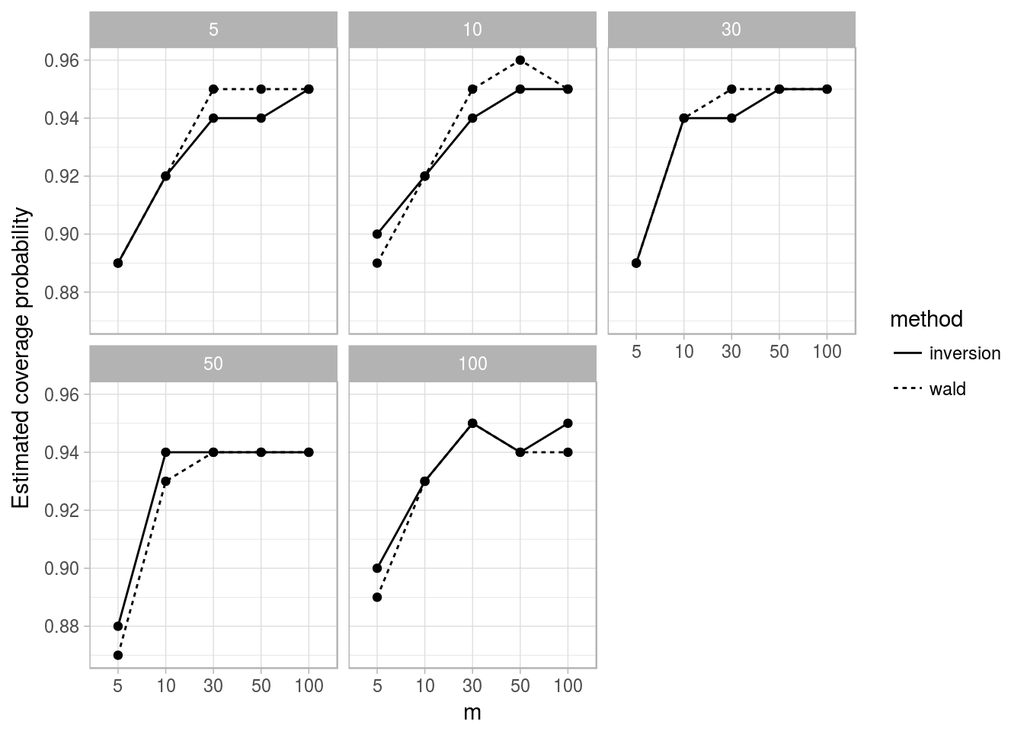

## Parametric bootstrap replicates of $\widehat{x}_0$

The bootstrap (Efron 1979) is a general-purpose computer-based method for assessing accuracy of estimators and forming confidence intervals for parameters. Jones and Rocke (1999) proposed a nonparametric bootstrap algorithm for controlled calibration with independent observations. However, since our application involves dependent observations, the nonparametric bootstrap does not easily apply, and instead, we adopt a parametric approach. In a parametric bootstrap, new samples are generated from a fitted parametric model, rather than sampling with replacement directly from the data. Fortunately, the parametric bootstrap confidence intervals are usually more accurate than nonparametric ones; however, by sampling from a fitted parametric family, we are implicitly assuming that we have the “correct model”.

Let $\widehat{\sigma}_0^2$ be an estimate of the variance of the new observation $\mathcal{Y}_0$. An algorithm for bootstrapping $\widehat{x}_0$ in an LMM is given below. Note that step (3) is crucial for calibration problems because we need to treat $y_0$ as a random quantity in the bootstrap simulation, otherwise the variability of $\widehat{x}_0$ will be underestimated; see, for example, Jones and Rocke (1999) and Greenwell and Kabban (2014).

- Fit an LMM (1) to the data and obtain estimates $\widehat{\boldsymbol{\beta}}$, $\widehat{\boldsymbol{D}}$, and $\widehat{\sigma}^2$.
  1. Define $\boldsymbol{y}^\star = \boldsymbol{X}\widehat{\boldsymbol{\beta}} + \boldsymbol{Z}\boldsymbol{b}^\star + \boldsymbol{\epsilon}^\star$, where $\boldsymbol{b}^\star \sim \mathcal{N}_q\left(\boldsymbol{0}, \widehat{\boldsymbol{D}}\right)$ and $\boldsymbol{\epsilon}^\star \sim \mathcal{N}_N\left(\boldsymbol{0}, \widehat{\sigma}_\epsilon^2\boldsymbol{I}\right)$;
  2. Update the original model using $\boldsymbol{y}^\star$ as the response vector to obtain $\widehat{\boldsymbol{\beta}}^\star$ and $\widehat{\sigma}_0^{2\star}$;
  3. Generate $y_0^\star \sim \mathcal{N}\left(y_0, \widehat{\sigma}_0^{2\star}\right)$;
  4. Define $\widehat{x}_0^\star = f^{-1}\left(y_0^\star; \widehat{\boldsymbol{\beta}}^\star\right)$;
- Repeat steps (1)-(4) $R$ times.

There are many bootstrap confidence interval procedures, for instance: the percentile method (Efron 1979), the studentized bootstrap $t$ method (Efron 1982), and the double bootstrap method (Hall 1986). For a good overview of these confidence interval procedures and more, see Davison and Hinkley (1997), chap. 5, and Boos and Stefanski (2013), chap. 11. In the next section, we discuss how to use this algorithm to adjust the previously discussed inversion interval.

It is possible to adopt a Bayesian approach to obtain the posterior distribution of $x_0$. However, as discussed in Hoadley (1970) (and the commenting articles), finding a prior for $x_0$ is not always straightforward, even in the case with independent observations. For the bladder volume example, it seems that any prior with positive support would be reasonable.

### A bootstrap adjusted inversion interval for $x_0$

Huet (2004) suggests a bootstrap modification of the usual inversion interval in nonlinear regression models with dependent data. In a similar fashion, we could use the parametric bootstrap to adjust $CI_I\left(x_0\right)$ to account for the variability of the estimated variance components. The inversion interval assumes that the *predictive pivot*
$$Q_I = \frac{\mathcal{Y}_0-f\left(x; \widehat{\boldsymbol{\beta}}\right)}{\left\{ \widehat{VAR}\left[\mathcal{Y}_0 - f\left(x; \widehat{\boldsymbol{\beta}}\right)\right] \right\}^{1/2}}$$
has a $\mathcal{N}\left(0, 1\right)$ distribution. A bootstrap modified inversion interval would instead use the bootstrap distribution of
$$Q_I^\star = \frac{\mathcal{Y}_0^\star-f\left(\widehat{x}_0; \widehat{\boldsymbol{\beta}}^\star\right)}{\left\{ \widehat{VAR}\left[\mathcal{Y}_0 - f\left(\widehat{x}_0; \widehat{\boldsymbol{\beta}}^\star\right)\right] \right\}^{1/2}},$$
to estimate the sampling distribution of $Q_I$. If $\widehat{F}_{Q_I}$ is the empirical distribution function for a sample of $R$ bootstrap replicates of $Q_I$, then the modified inversion interval for $x_0$ is given by
$$CI_I^\star\left(x_0\right) = \left\{ x: \widehat{F}_{Q_I}\left(\alpha/2\right) \le Q_I \le \widehat{F}_{Q_I}\left(1-\alpha/2\right) \right\}.$$

## Bladder volume example

For illustration, we consider the bladder volume data which first appeared in Haylen et al. (1989) and again in Brown (1993), pg. 7, and Oman (1998). The study sample consisted of a series of 23 female patients attending a urodynamic clinic. After successfully voiding their bladder, each subject was injected with sterile water in additions of 1, 1.5, and then 2.5 cl increments up to a final cumulative total of 17.5 cl. At each true volume $V$ a measure of height ($H$) in mm and depth ($D$) in mm of largest ultrasound bladder images were taken. The product $HD = H \times D$ was taken as a measure of liquid volume."

A spaghetti plot of the raw data is displayed in the left side of Figure 1. As noted by Brown (1993), $\left(H \times D\right) ^ {3/2}$ should be linearly related to $V$. The transformed version of the data is displayed in the right side of Figure 1.

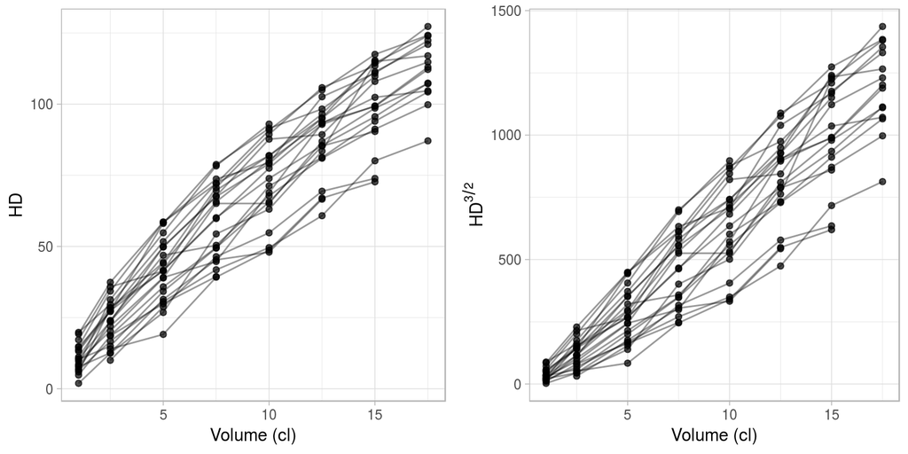

```
> bladder.lme <- lme(HD ^ (3 / 2) ~ volume, data = bladder,
+                    random = list(subject = pdDiag( ~ volume)))
```

Fixed-effects t-table for the random intercept and slope model fit to the bladder volume data.

|  | Value | Std.Error | DF | t-value | p-value |
| --- | --- | --- | --- | --- | --- |
| (Intercept) | -53.8 | 11.60 | 142 | -4.64 | 0 |
| volume | 69.1 | 3.11 | 142 | 22.19 | 0 |

The `pdDiag` function forces a diagonal variance-covariance structure on the random-effects; hence, a covariance of zero. For an in-depth treatment on fitting LMMs using the `nlme` software, see J.C. Pinheiro and Bates (2000).

### The investr package

| Argument | Description |
| --- | --- |
| `object` | An object that inherits from class `"lm"`, `"glm"`, `"nls"`, or `"lme"`. |
| `y0` | The value of the observed response(s) or specified value of the mean response. For `"glm"` objects, `y0` should be on the scale of the response variable |
| `interval` | The type of interval required. |
| `level` | A numeric scalar between 0 and 1 giving the confidence level for the interval to be calculated. |
| `mean.response` | Logical indicating whether confidence intervals should correspond to an individual response (`FALSE`) or a mean response (`TRUE`). For glm objects, this is always TRUE. |
| `lower` | The lower endpoint of the interval to be searched. |
| `upper` | The upper endpoint of the interval to be searched. |
| `tol` | The desired accuracy passed on to `uniroot`. Recommend a minimum of `1e-10`. |
| `maxiter` | The maximum number of iterations passed on to `uniroot`. |
| `q1` | Optional lower cutoff to be used in forming confidence intervals. Only used when `object` inherits from class `"lme"`. Defaults to `stats::qnorm((1+level)/2)`. |
| `q2` | Optional upper cutoff to be used in forming confidence intervals. Only used when `object` inherits from class `"lme"`. Defaults to `stats::qnorm((1-level)/2)`. |

Returning to the bladder volume example, suppose we obtained an ultrasound measurement from a new patient for which $HD^{3/2} = 500$ (that’s roughly 63 on the original scale). What is the true volume of fluid ($x_0$) in the patients bladder? We can estimate the true volume and form an approximate 95% confidence interval using the methods discussed previously. The point estimate is simply given by
$$\widehat{x}_0 = \frac{500 + 53.83164}{69.09491} = 8.0155 \text{ (cl)}.$$
This estimate can be obtained in R as follows:

```
> library(investr)  # install.packages("investr")
> (x0.est <- invest(bladder.lme, y0 = 500, interval = "none"))
```

```
## volume
##   8.02
```

The code used by `invest` to obtain this point estimate is basically

```
> fun <- function(x) {
+   predict(bladder.lme, newdata = list("volume" = x), level = 0) - 500
+ }
> uniroot(fun, lower = 1, upper = 17.5, tol = 1e-10, maxiter = 1000)$root
```

```
## [1] 8.02
```

In other words, `invest` relies on the R function `uniroot` from the `stats` package to solve the equation $f\left(x; \widehat{\boldsymbol{\beta}}\right) - y_0 = 0$ numerically for $x$. If the solution does not lie in the range of predictor values, then an error message will be displayed, as in

```
> invest(bladder.lme, y0 = 1500)
```

```
## Error: Point estimate not found in the search interval (1, 17.5). Try tweaking the values of lower and upper.
```

The values for `lower`, `upper`, `tol`, and `maxiter` are controlled via the arguments of the same name listed in Table 2.

```
> invest(bladder.lme, y0 = 500, interval = "Wald")
```

```
## estimate    lower    upper       se
##     8.02     4.18    11.85     1.95
```

The standard error is computed using a First-order Taylor series approximation. Similar to the code snippet shown below, `invest` calls the `stats` function `numericDeriv` to numerically evaluate the gradient of $\widehat{x}_0$ as a function of $y_0$ and $\widehat{\boldsymbol{\beta}}$.

```
> x0Fun <- function(params) {  # x0 as function of y0 and fixed effects
+   fun <- function(x) {
+     X <- model.matrix(eval(bladder.lme$call$fixed)[-2],
+                       data = data.frame("volume" = x))
+     X %*% params[-length(params)] - params[length(params)]
+   }
+   uniroot(fun, lower = 1, upper = 17.5, tol = 1e-10,
+           maxiter = 1000)$root
+ }
> params <- c(fixef(bladder.lme), 500)
> covmat <- diag(3)  # set up variance-covariance matrix
> covmat[1:2, 1:2] <- vcov(bladder.lme)  # fixed effects var/cov matrix
> covmat[3, 3] <- 17572.35  # VAR[Y_0]
> gv <- attr(numericDeriv(quote(x0Fun(params)), "params"), "gradient")
> (se <- as.numeric(sqrt(gv %*% covmat %*% t(gv))))
```

```
## [1] 1.95
```

Alternatively, one can use the very useful `deltaMethod` function from the `car` package (Fox and Weisberg 2011) to obtain `se`:

```
> library(car)  # install.packages("car")
> params <- c(fixef(bladder.lme), 500)
> covmat <- diag(3)  # set up var/cov matrix
> covmat[1:2, 1:2] <- vcov(bladder.lme)  # fixed effects var/cov matrix
> covmat[3, 3] <-  17572.35  # VAR[Y_0]
> names(params) <- c("b0", "b1", "y0")
> (se <- deltaMethod(params, g = "(y0 - b0)/b1",  vcov. = covmat)$SE)
```

```
## [1] 1.95
```

The only drawback here is that `deltaMethod` relies on the `stats` package symbolic differentiation function `D`; hence, $\widehat{x}_0 = f^{-1}\left(y_0; \widehat{\boldsymbol{\beta}}\right)$ has to be obtainable in closed-form.

To obtain the approximate inversion interval , we specify `interval = "inversion"` (the default) as in the following:

```
> invest(bladder.lme, y0 = 500, interval = "inversion")
```

```
## estimate    lower    upper
##     8.02     4.23    11.92
```

```
> N <- nrow(bladder)  # total sample size
> tvals <- qt(c(0.025, 0.975), df = N-1)  # quantiles from t dist with N-1 d.f.
> invest(bladder.lme, y0 = 500, q1 = tvals[1], q2 = tvals[2])
```

```
## estimate    lower    upper
##     8.02     4.20    11.95
```

### The parametric bootstrap

Since we will be using the `lme4` package, we need to refit the model using the `lmer` function (notice the different syntax required for speicfying the same random effects structure):

```
> library(lme4)  # install.packages("lme4")
> bladder.lmer <- lmer(HD^(3/2) ~ volume + (0+1|subject) + (0+volume|subject),
+                      data = bladder)
```

Theoretically, the parameter estimates from this model should be the same as those from `bladder.lme`; however, there are likely to be small numerical differences between the two. For this reason, let us re-estimate $\widehat{x}_0$ using `bladder.lmer`. Since `invest` does not work on objects fit using `lmer` from the `lme4` package (i.e., object of class `"lmerMod"`), we have to do things manually:

```
> fe <- unname(fixef(bladder.lmer))  # fixed effects without dimnames attribute
> (x0.est <- (500 - fe[1]) / fe[2])
```

```
## [1] 8.02
```

Also, for convenience, we define the following function which estimates $VAR\left[\mathcal{Y}|x\right] = \sigma_0^2 + x^2\sigma_1^2 + \sigma^2$ for a given value of $x$:

```
> var.y <- function(object, x) {
+   vc <- as.data.frame(lme4::VarCorr(object))$vcov
+   vc[1] + vc[2]*x^2 + vc[3]
+ }
```

For example, to estimate $\sigma_0^2 = \widehat{VAR}\left[\mathcal{Y}_0\right]$, we have `var.y(bladder.lmer, x = x0.est)`, which gives `1.757\times 10^{4}`, the same value used in the previous section.

Although we could easily compute all the bootstrap intervals previously discussed in one call to `bootMer` and `boot.ci`, we will discuss and compute each interval separately.

```
> boot.fun <- function(.) {  # bootstrap function
+
+   # Point estimate
+   var.y0.boot <- var.y(., x = x0.est)  # VAR[Y0]
+   fe.boot <- unname(fixef(.))  # fixed effects
+   if (all(getME(., "y") == bladder$HD^(3/2))) {
+     y0.boot <- 500
+   } else {
+     y0.boot <- rnorm(1, 500, sqrt(var.y0.boot))
+   }
+   x0.boot <- (y0.boot - fe.boot[1])/fe.boot[2]
+
+   # Approximate variance
+   covmat <- diag(3)
+   covmat[1:2, 1:2] <- as.matrix(vcov(.))
+   covmat[3, 3] <-  var.y0.boot
+   params <- c("b0" = fe.boot[1], "b1" = fe.boot[2], "y0" = y0.boot)
+   dm <- deltaMethod(params, g = "(y0 - b0)/b1",  vcov. = covmat)
+   var.x0.boot <- dm$SE^2
+
+   # Approximate predictive pivot
+   mu0.boot <-  as.numeric(crossprod(fe.boot, c(1, x0.est)))
+   var.mu0.boot <- t(c(1, x0.est)) %*% as.matrix(vcov(.)) %*% c(1, x0.est)
+   QI.boot <- (y0.boot - mu0.boot)/sqrt(var.y0.boot + var.mu0.boot)
+
+   # Return vector of results
+   c(x0.boot, var.x0.boot, QI.boot)
+
+ }
> pb <- bootMer(bladder.lmer, boot.fun, nsim = 9999, seed = 105)  # run simulation
```

The `bootMer` function returns an object of class `boot` which can then be processed via the `boot` package to obtain the various bootstrap confidence intervals discussed earlier. A basic summary of `pb` is given by

```
> library(boot)  # load boot package
> summary(pb)
```

```
##      R original bootBias bootSE bootMed
## 1 9999     8.02 -0.00219   1.97  8.0186
## 2 9999     3.82  0.05243   1.02  3.7702
## 3 9999     0.00 -0.00810   1.00  0.0016
```

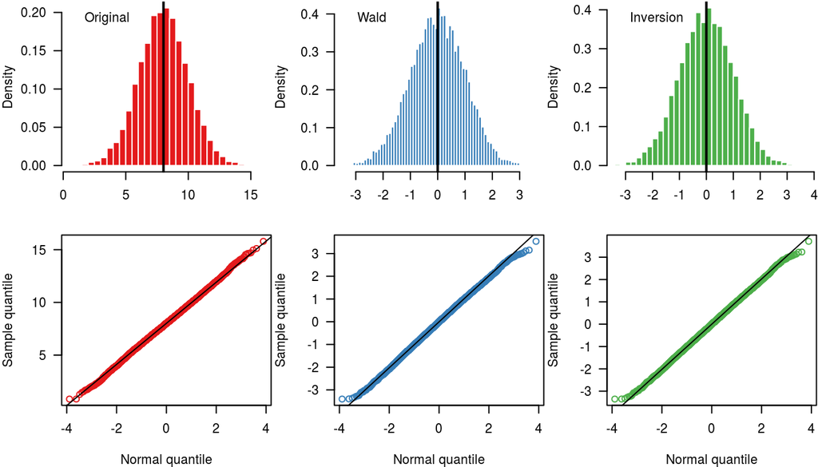

Graphical summary of bootstrap replicates. $R = 9,999$ bootstrap replicates of $\widehat{x}_0$ (left), $Q_W$ (middle), and $Q_I$ (right).

```
> boot.ci(pb, type = c("norm", "perc", "stud"), index = 1:2)
```

```
## BOOTSTRAP CONFIDENCE INTERVAL CALCULATIONS
## Based on 9999 bootstrap replicates
##
## CALL :
## boot.ci(boot.out = pb, type = c("norm", "perc", "stud"), index = 1:2)
##
## Intervals :
## Level      Normal            Studentized          Percentile
## 95%   ( 4.15, 11.89 )   ( 4.30, 11.99 )   ( 4.05, 11.91 )
## Calculations and Intervals on Original Scale
```

The bootstrap adjusted inversion interval can be computed as easily as the ordinary inversion interval, except we need to supply `invest` with the estimated quantiles $\widehat{F}_{Q_I}\left(0.025\right)$ and $\widehat{F}_{Q_I}\left(0.975\right)$:

```
> QI.boot <- pb$t[, 3]  # bootsrap replicates of Q_I
> qvals <- quantile(QI.boot, c(0.025, 0.975))  # sample quantiles
> invest(bladder.lme, y0 = 500, q1 = qvals[1], q2 = qvals[2])
```

```
## estimate    lower    upper
##     8.02     4.28    12.02
```

[output not shown]

Table 3. Summary of results for the bladder volume example. A $\star$ symbol indicates a parametric bootstrap-based confidence interval

Fixed-effects t-table for the random intercept and slope model fit to the bladder volume data.

|  | Estimate | Std. Error | t value |
| --- | --- | --- | --- |
| (Intercept) | 1.887 | 1.714 | 1.1 |
| volume | 8.656 | 0.318 | 27.2 |
| I(volume^2) | -0.146 | 0.014 | -10.1 |

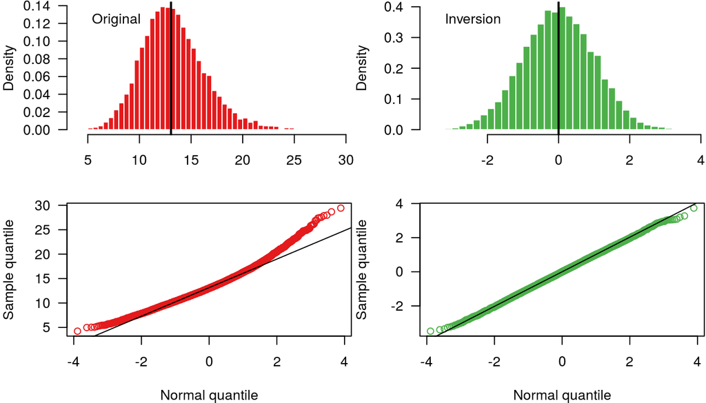

## Conclusion

We have discussed a number of confidence interval procedures for statistical calibration in linear models with random coefficients with a single level of grouping. We have described two R packages for implementing these procedures: `investr` and `lme4`. The `investr` package can be used for obtaining the asymptotic confidence intervals (i.e., the Wald-based and inversion confidence intervals). We also showed how the `lme4` package can be used to obtain calibration intervals based on a parametric bootstrap using the recently added `bootMer` function. Future work will likely extend the methods discussed in this paper to more complicated cases such as nonlinear mixed-effects models and multi-level hierarchical models (i.e., more than one grouping variable).

## References

Bates, Douglas, Martin Maechler, Ben Bolker, and Steven Walker. 2014. *Lme4: Linear Mixed-Effects Models Using Eigen and S4*. http://CRAN.R-project.org/package=lme4.

Boos, D.D., and L.A. Stefanski. 2013. *Essential Statistical Inference: Theory and Methods*. Springer Texts in Statistics. Springer London, Limited.

Brown, P.J. 1993. *Measurement, Regression, and Calibration*. Oxford Science Publications. Clarendon Press.

Davison, A. C., and D. V. Hinkley. 1997. *Bootstrap Methods and Their Applications*. Cambridge Series in Statistical and Probabilistic Mathematics. Cambridge: Cambridge University Press.

Demidenko, E. 2013. *Mixed Models: Theory and Applications with R*. Wiley.

Efron, B. 1979. “Bootstrap Methods: Another Look at the Jackknife.” *The Annals of Statistics* 7 (1): 1–26.

———. 1982. *The Jackknife, the Bootstrap, and Other Resampling Plans*. Society for Industrial; Applied Mathematics.

Fox, John, and Sanford Weisberg. 2011. *An R Companion to Applied Regression*. Second. Thousand Oaks CA: Sage. http://socserv.socsci.mcmaster.ca/jfox/Books/Companion.

Graybill, F. A. 1976. *Theory and Application of the Linear Model*. Duxbury Classic Series. Pacific Grove, CA: Duxbury.

Greenwell, Brandon M. 2014. “Topics in Statistical Calibration.” PhD thesis, Air Force Institute of Technology.

Greenwell, Brandon M., and Christine M. Schubert Kabban. 2014. “Investr: An R Package for Inverse Estimation.” *The R Journal* 6 (1): 90–100. http://journal.r-project.org/archive/2014-1/greenwell-kabban.pdf.

Hall, Peter. 1986. “On the Bootstrap and Confidence Intervals.” *The Annals of Statistics* 14 (4): 1431–52.

Haylen, B. T., M. I. Frazer, J. R. Sutherst, and C. R. West. 1989. “Transvaginal Ultrasound in the Assessment of Bladder Volumes in Women: Preliminary Report.” *British Journal of Urology* 63 (2): 149–51.

Hoadley, Bruce. 1970. “A Bayesian Look at Inverse Linear Regression.” *Journal of the American Statistical Association* 65 (329): 356–69.

Huet, S. 2004. *Statistical Tools for Nonlinear Regression: A Practical Guide with S-Plus and R Examples*. Springer Series in Statistics. Springer.

Jones, Geoffrey, and David M. Rocke. 1999. “Bootstrapping in Controlled Calibration Experiments.” *Technometrics* 41 (3): 224–33.

Laird, Nan M., and James H. Ware. 1982. “Random-Effects Models for Longitudinal Data.” *Biometrics* 38 (4): 963–74.

McCulloch, C. E., S. R. Searle, and J. M. Neuhaus. 2008. *Generalized, Linear, and Mixed Models*. Wiley.

Oman, Samuel D. 1998. “Calibration with Random Slopes.” *Biometrika* 85 (2): 439–49.

Osborne, C. 1991. “Calibration: A Review.” *International Statistical Review* 59 (3): 309–36.

Pinheiro, J.C., and D.M. Bates. 2000. *Mixed-Effects Models in S and S-Plus*. Statistics and Computing. Springer.

Pinheiro, Jose, Douglas Bates, Saikat DebRoy, Deepayan Sarkar, and R Core Team. 2013. *Nlme: Linear and Nonlinear Mixed Effects Models*.

Seber, G.A.F., and C.J. Wild. 2003. *Nonlinear Regression*. Wiley Series in Probability and Statistics. Wiley.

Wickham, Hadley. 2011. “The Split-Apply-Combine Strategy for Data Analysis.” *Journal of Statistical Software* 40 (1): 1–29. http://www.jstatsoft.org/v40/i01/.